# Music Genre Classification

In this project, I will build a machine learning algorithm to classify music genres using audio features. The goal is to acchieve an acurracy over 75%.

```python
import numpy as np
import pandas as pd
import librosa
from datasets import load_from_disk
from IPython.display import Audio, display
from tqdm import tqdm_notebook as tqdm
from sklearn.base import BaseEstimator, TransformerMixin
import matplotlib.pyplot as plt
from sklearn.pipeline import Pipeline
from sklearn.preprocessing import StandardScaler
from sklearn.linear_model import LogisticRegression
from sklearn.model_selection import GridSearchCV
import seaborn as sns
from sklearn.decomposition import PCA
from sklearn.model_selection import train_test_split
from sklearn.metrics import accuracy_score, classification_report, ConfusionMatrixDisplay
import gc
from sklearn.ensemble import RandomForestClassifier
import xgboost as xgb
from sklearn.svm import SVC
```

### Dataset Description

The dataset consists of music samples from various genres, including:

- **Genres**: `Blues`, `Classical`, `Country`, `Disco`, `HipHop`, `Jazz`, `Metal`, `Pop`, `Reggae`, and `Rock`.

The dataset is a bit messy and includes some **unlabeled data** and **empty audio files**. We have provided basic preprocessing, but more in-depth data cleaning, feature extraction, and preparation will be a part of your assignment.

Let's import the audio dataset using the Hugging Face datasets library.

```python
gc.collect()
dataset = load_from_disk('audio_data')
```

```python
print(f"Num of samples in the dataset: {len(dataset)}")
```

```
Num of samples in the dataset: 1230
```

Let's take a glance at a sample from the dataset

```python
entry = dataset[10] # Gives the row 10 of the hole dictionary => ONE audio file

audio_array = entry['audio']['array']   # Key Audio is also a dict -> Chooses their the key array.
sampling_rate = entry['audio']['sampling_rate'] # Audio Hz (Measurment Rate)

print(f"Element: {entry}")
print(f"File Path: {entry['file']}")
print(f"Number of Samples: {len(audio_array)}")
print(f"Sampling Rate: {sampling_rate} Hz")

audio_length_seconds = len(audio_array) / sampling_rate # Lengh in seconds
print(f"Audio Length: {audio_length_seconds:.2f} seconds")  # :.2f => Rounding on 2 decimal

genre_id = entry['genre']
genre_label = dataset.features['genre'].int2str(genre_id)
print(f"Genre (ID): {genre_id}")
print(f"Genre (Label): {genre_label}")

display(Audio(audio_array, rate=sampling_rate))
```

```
Element: {'file': 'audio_data/country/country.00247.wav', 'audio': {'path': 'country.00247.wav', 'array': array([-0.01055908, -0.01712036, -0.02111816, ...,  0.03747559,
        0.01239014, -0.03366089], shape=(661794,)), 'sampling_rate': 22050}, 'genre': 2}
File Path: audio_data/country/country.00247.wav
Number of Samples: 661794
Sampling Rate: 22050 Hz
Audio Length: 30.01 seconds
Genre (ID): 2
Genre (Label): country
```

[interactive chart not shown]

**Draw a plot with distribution of the classes**

Create a visualization (e.g., bar chart or histogram) that shows how many samples belong to each class. This helps identify whether the dataset is balanced or if some classes are underrepresented.

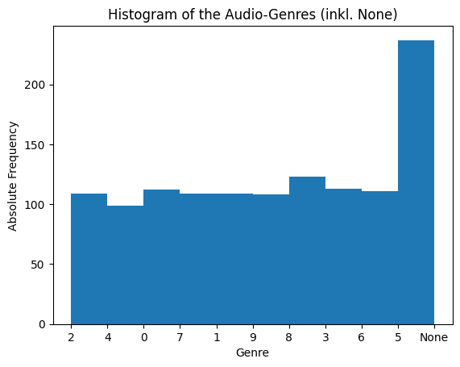

```python
# write code to draw the distribution
dataset["genre"]                # Showing the raw genre-vector.
dataset.features["genre"]       # Showing the genre-lable-list.

# Checking for Non-values
sum([i is None for i in dataset["genre"]])

# Plotting the Genres
genre_as_str = [str(i) for i in dataset["genre"]]
plt.hist(genre_as_str)
plt.title("Histogram of the Audio-Genres (inkl. None)")
plt.xlabel("Genre")
plt.ylabel("Absolute Frequency")
```

**Draw distribution of lengths of audios**

Plot the distribution of audio lengths in the dataset to analyze how durations vary across samples.

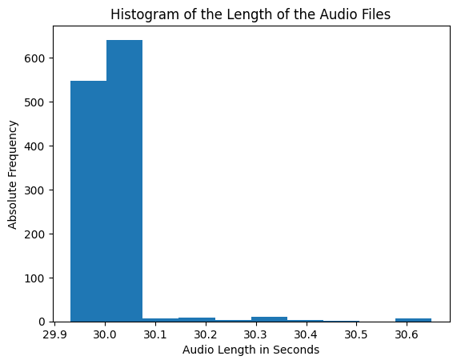

```python
# Extracting all the arrays from dataset["audio"]
array_list = [i["array"] for i in dataset["audio"]]

# Measuring the lengh of the audio file per audio file
array_list_len = [len(i)/sampling_rate for i in array_list]

# Plotting the Distribution of Audio Length
plt.hist(array_list_len, density=False)
plt.title("Histogram of the Length of the Audio Files")
plt.xlabel("Audio Length in Seconds")
plt.ylabel("Absolute Frequency")
```

**Delete empty samples**

Implement the function to remove empty samples (audios with silence only)

```python
# First, remove array_list again to free RAM space:
del array_list
```

```python
def filter_empty_samples(x):
    if np.std(x["audio"]["array"]) != 0:
        return True
    else:
        return False
```

```python
filtered_dataset = dataset.filter(
    filter_empty_samples,
    num_proc=1,
    batched=False,
    writer_batch_size=100,
    load_from_cache_file=True
)
```

```python
assert len(filtered_dataset) == 970, "Your filtering function is wrong"
```

**Delete unlabeled samples**

Implement the function to remove unlabeled samples.

```python
def filter_empty_labels(x):
    if x["genre"] != None:
        return True
    else:
        return False
```

```python
filtered_dataset = filtered_dataset.filter(filter_empty_labels)
```

```python
assert len(filtered_dataset) == 848, "Your filtering function is wrong"

# Checking for other None-Values
sum([i == None for i in dataset["file"]])
sum([i == None for i in dataset["audio"]])
```

```
0
```

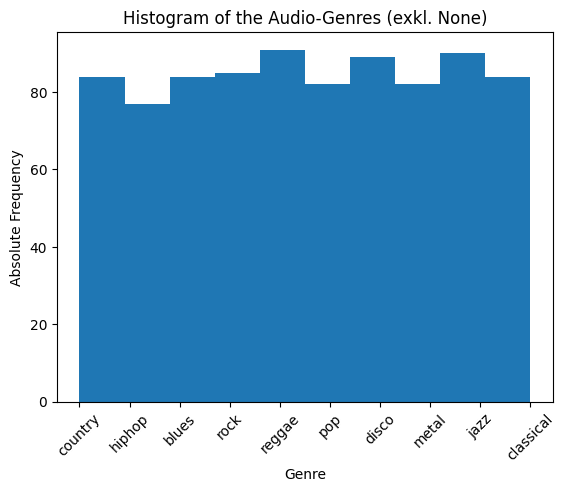

```python
# Plotting the Genre-Distribution of the filtered dataset

label_strings = filtered_dataset.features["genre"].int2str(filtered_dataset["genre"])   # Translates the numeric features back to strings (argument of int2str = legend of numbers)

plt.hist(label_strings)
plt.title("Histogram of the Audio-Genres (exkl. None)")
plt.xlabel("Genre")
plt.xticks(rotation=45)
plt.ylabel("Absolute Frequency")
```

### **Mel Frequency Cepstral Coefficients**

**[Mel Frequency Cepstral Coefficients (MFCCs)](https://en.wikipedia.org/wiki/Mel-frequency_cepstrum)** are commonly used in audio analysis to capture key features of sound. They help represent the important characteristics of an audio signal, making them ideal for tasks like music genre classification and speech recognition.

We're not going to dive deep into the complex details of audio processing, but it's useful to know that MFCCs help simplify raw audio data while retaining important information.

#### Basic Steps in MFCC Extraction:

1. **Frequency Domain Conversion**: The audio signal is split into short frames, and we apply the Fourier Transform to convert them from the time domain to the frequency domain.
2. **Mel Scale Mapping**: The frequency spectrum is converted to the Mel scale, which better represents how humans perceive sound, emphasizing lower frequencies.
3. **Logarithm and DCT**: After mapping to the Mel scale, we apply a logarithm and the Discrete Cosine Transform (DCT) to get the MFCCs. These summarize the "cepstral" information of the audio signal.

The parameter `n_mfcc` controls **how many MFCC coefficients** are extracted for each frame. For example, setting `n_mfcc=8` means we extract 8 coefficients, where lower coefficients capture broad audio features, and higher coefficients capture the more finer details.

#### Why MFCCs Are Important:

MFCCs help capture the **tonal quality** of the sound and reduce the complexity of the raw audio signal. By summarizing the audio into a smaller set of features, they allow machine learning models to classify and recognize different types of sounds more effectively.

In this notebook, we'll use the **mean** and **variance** of the MFCCs over time to create a robust feature set for our classification model. Adjusting the `n_mfcc` parameter allows us to control the number of features extracted for each audio sample.

#### **Additional Features**

Consider exploring additional audio features to enhance your model's performance. There are various acoustic properties you could extract from the audio signals, such as zero crossings, harmonic-percussive separation, tempo, spectral centroids, spectral rolloff, chromagram, RMS energy, spectral bandwidth, etc. When working with these features, it's often useful to compute summary statistics like the mean and variance across the audio sample. These summary statistics can capture the overall characteristics and variability of the feature, reducing the dimensionality of your data while retaining important information. Experimenting with these features and their statistical summaries could potentially improve your model's accuracy and robustness in distinguishing between different audio characteristics.*

```python
class Feature_Extractor(BaseEstimator, TransformerMixin):

    def __init__(self, n_mfcc=20):
        self.n_mfcc = n_mfcc

    def fit(self, X, y=None):
        return self

    def transform(self, X):
        features = {"mfcc_mean": [],
                    "mfcc_var": [],
                    "rms_mean": [],
                    "rms_var": [],
                    "spectral_centroid_mean": [],
                    "spectral_centroid_var": [],
                    "zero_mean_crossing_mean": [],
                    "zero_mean_crossing_var": [],
                    "spectral_contrast_mean": [],
                    "spectral_contrast_var": []}
        for audio_sample in tqdm(X):
            # Extracting each single Audio-Sample-Array
            audio_array = audio_sample['array']
            sr = audio_sample['sampling_rate']

            # Extracting MFCC
            def extract_mfcc(audio_array, n_mfcc):
                mfccs = librosa.feature.mfcc(y=audio_array, sr=sr, n_mfcc=n_mfcc)
                features["mfcc_mean"].append(np.mean(mfccs, axis=1))    # Fügt 20 Mittelwerte hinzu
                features["mfcc_var"].append(np.var(mfccs, axis=1))      # Fügt 20 Varianzen hinzu
            extract_mfcc(audio_array=audio_array, n_mfcc=self.n_mfcc)

            # Extracting RMS
            rms = librosa.feature.rms(y=audio_array)[0] # [0] weil librosa oft 2D-Arrays zurückgibt
            features["rms_mean"].append(np.mean(rms)) # Fügt 1 Mittelwert hinzu
            features["rms_var"].append(np.var(rms))  # Fügt 1 Varianz hinzu

            # Extracting Spectral Centroid
            spectral_centroid = librosa.feature.spectral_centroid(y=audio_array, sr=sr)[0]
            features["spectral_centroid_mean"].append(np.mean(spectral_centroid))
            features["spectral_centroid_var"].append(np.var(spectral_centroid))

            # Extracting Zero Crossing Rate
            zcr = librosa.feature.zero_crossing_rate(y=audio_array)[0]
            features["zero_mean_crossing_mean"].append(np.mean(zcr))
            features["zero_mean_crossing_var"].append(np.var(zcr))

            # Extracting Sepctral Contrast
            contrast_matrix = librosa.feature.spectral_contrast(y=audio_array, sr=sr)
            features["spectral_contrast_mean"].append(np.mean(contrast_matrix, axis=1))
            features["spectral_contrast_var"].append(np.var(contrast_matrix, axis=1))

        # Flattening Features and transforming to Data Frame
        df_features = pd.DataFrame()
        num_mfcc = len(features["mfcc_mean"][0])
        for i in range(num_mfcc):
            df_features[f"mfcc_{i+1}_mean"] = [x[i] for x in features["mfcc_mean"]]
            df_features[f"mfcc_{i+1}_var"] = [x[i] for x in features["mfcc_var"]]

        num_scm = len(features["spectral_contrast_mean"][0])
        for i in range(num_scm):
            df_features[f"spectral_contrast_{i+1}_mean"] = [x[i] for x in features["spectral_contrast_mean"]]
            df_features[f"spectral_contrast_{i+1}_var"] = [x[i] for x in features["spectral_contrast_var"]]

        # Adding the other features to the df_features Data Frame.
        keys = ["rms_mean", "rms_var", "spectral_centroid_mean", "spectral_centroid_var", "zero_mean_crossing_mean", "zero_mean_crossing_var"]
        for i in keys:
            df_features[i] = features[i]

        return df_features

features = Feature_Extractor(n_mfcc=40).transform(filtered_dataset["audio"])
```

#### **Feature Analysis**

Don´t forget to optimize the use of features, identifying and handling irrelevant and reduntant features. Then use feature ranking to identify which features are more influential, and evaluate quantitatively how many top-features to retain.

Let's take a look at the output of the function. We will pass there just 2 samples from the dataset.

```python
features.iloc[:2, ]
```

|  | mfcc_1_mean | mfcc_1_var | mfcc_2_mean | mfcc_2_var | mfcc_3_mean | mfcc_3_var | mfcc_4_mean | mfcc_4_var | mfcc_5_mean | mfcc_5_var | ... | spectral_contrast_6_mean | spectral_contrast_6_var | spectral_contrast_7_mean | spectral_contrast_7_var | rms_mean | rms_var | spectral_centroid_mean | spectral_centroid_var | zero_mean_crossing_mean | zero_mean_crossing_var |
| --- | --- | --- | --- | --- | --- | --- | --- | --- | --- | --- | --- | --- | --- | --- | --- | --- | --- | --- | --- | --- | --- |
| 0 | -69.836278 | 2341.101347 | 124.207701 | 580.461335 | -32.482371 | 329.799566 | 47.689801 | 167.005379 | 1.400885 | 125.102031 | ... | 20.659933 | 13.783267 | 41.170030 | 10.792918 | 0.218017 | 0.003456 | 1754.316930 | 324963.277009 | 0.097413 | 0.002088 |
| 1 | -191.643297 | 3301.314391 | 41.318241 | 403.273174 | 5.013655 | 447.922087 | 65.453821 | 220.996266 | -4.320506 | 210.413597 | ... | 16.043799 | 4.933649 | 41.233764 | 8.695768 | 0.067212 | 0.001955 | 3185.548897 | 426097.673331 | 0.152132 | 0.005553 |

2 rows × 100 columns

**(ADV) Analyze correlation of the features**

Plot correlation diagram and conclude which features are too much correlated and could be removed.

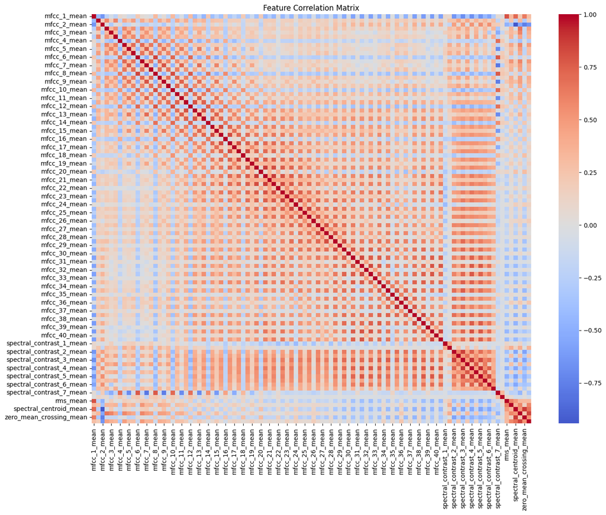

```python
features.head()

# # Analyzing Correlation
corr_matrix = features.corr()

# Visualizing Feature-Cross-Correlation
plt.figure(figsize=(16, 12))
sns.heatmap(corr_matrix, cmap='coolwarm', center=0)
plt.title("Feature Correlation Matrix")
plt.show()
```

**(ADV) Analyze feature importance**

Analyze the importance of each feature used in the model to understand which variables have the greatest impact on predictions.

```python
# ----------------------------------------- Version 1: Random Forest -----------------------------------------

# =========================================
# FEATURE-RANKING by using a Random-Forest
# =========================================
# The following function expects "feature_data" to be a pd.DataFrame with a flatted
# Feature Structure. And "labels" is expected to be a list with the correct labels.
def feature_ranking_extractor(feature_data, labels):
    # Checking feature_data Properties
    if isinstance(feature_data, pd.DataFrame):
        # Preparing Data for Random-Forest
        X = feature_data
        y = labels

        # Train-Test Split
        X_train, X_test, y_train, y_test = train_test_split(X, y, test_size=0.2, random_state=42)

        # Train Random-Forest
        rf_model = RandomForestClassifier(n_estimators=100,
                                        max_depth=10,
                                        random_state=42)
        rf_model.fit(X_train, y_train)
        print(f"Random-Forest Acurracy: {rf_model.score(X_test, y_test):.3f}")

        # Extrcting Feature-Ranking by Gini-Importance
        feature_ranking = pd.DataFrame({
            "Feature": feature_data.columns,
            "Gini_Importance": rf_model.feature_importances_    #! Cumulated Gini-Impurity Decrease of that Feature
        }).sort_values(by="Gini_Importance", ascending=False)   #! Sum equals 1

        return feature_ranking
    else:
        raise TypeError("feature_data must be a Pandas.DataFrame")

# Acurracy by using all possible Features
feature_ranking = feature_ranking_extractor(features, filtered_dataset["genre"])

# Feature Ranking by Gini Importance
feature_ranking.head()
```

```
Random-Forest Acurracy: 0.671
```

|  | Feature | Gini_Importance |
| --- | --- | --- |
| 94 | rms_mean | 0.035125 |
| 88 | spectral_contrast_5_mean | 0.032616 |
| 95 | rms_var | 0.029783 |
| 0 | mfcc_1_mean | 0.025174 |
| 97 | spectral_centroid_var | 0.023901 |

```python
# =====================================================================
# RECURSIVE FEATURE CURVE: Accuracy vs. Amount of Regressors -> Getting the Values
# =====================================================================
def accuracy_extractor(feature_ranking_data, feature_data, labels):
    # Checking feature_ranking_data- & feature_data Properties
    if isinstance(feature_ranking_data, pd.DataFrame) and isinstance(feature_data, pd.DataFrame):
        # Extracting Feature Names
        feature_ranking_names = feature_ranking_data["Feature"]

        # Storing Results
        num_features = []
        train_accuracies = []
        test_accuracies = []

        # Defining Constants (Labels & Standardized Complete Features)
        y = labels
        X_std = pd.DataFrame(StandardScaler().fit_transform(feature_data), columns=feature_data.columns)

        # Estimating LogisticRegression with increasing Amount of Features - Starting with Best Ranked
        for i in tqdm(range(1, len(feature_ranking_names) + 1)):

            # Selecting the Features for the Model
            selected_features = feature_ranking_names[:i]
            X = X_std[selected_features]

            # Train-Test Split
            X_train, X_test, y_train, y_test = train_test_split(X, y, test_size=0.2, random_state=42)

            # Training the Model
            lr_model = LogisticRegression(max_iter=1000, random_state=42)
            lr_model.fit(X_train, y_train)

            # Calculating Accuracy
            num_features.append(i)
            train_accuracies.append(lr_model.score(X_train, y_train))
            test_accuracies.append(lr_model.score(X_test, y_test))

        # Summarizing Results
        df_curve = pd.DataFrame({
            "num_features": num_features,
            "train_accuracies": train_accuracies,
            "test_accuracies": test_accuracies
        })
        return df_curve
    else:
        raise TypeError("feature_ranking_data & feature_data must be Pandas DataFrames")

# Getting all acurracies with different amounts of Features
accuracies = accuracy_extractor(feature_ranking, features, filtered_dataset["genre"])
```

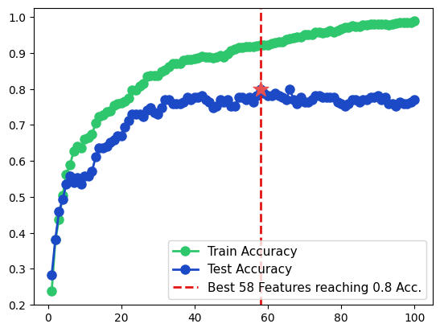

```python
# ================================================================
# RECURSIVE FEATURE CURVE: Accuracy vs. Amount of Regressors -> Visualization
# ================================================================
def curve(accuracies_data):
    # Extracting Best Amount of Features
    best_n_features = accuracies_data["num_features"][accuracies_data["test_accuracies"] == max(accuracies_data["test_accuracies"])].iloc[0]
    best_accuracy = accuracies_data["test_accuracies"][accuracies_data["num_features"] == best_n_features]

    # Plotting the Elbow-Curve
    plt.plot(accuracies_data.num_features,
             accuracies_data.train_accuracies,
             "o-",
             label="Train Accuracy",
             linewidth=2,
             markersize=8,
             color="#2fc76e")
    plt.plot(accuracies_data.num_features,
             accuracies_data.test_accuracies,
             "o-",
             label="Test Accuracy",
             linewidth=2,
             markersize=8,
             color="#1c49c5")

    # Adding Situation of Best Feature-Amount
    plt.axvline(best_n_features,
               color="#e11515",
               linestyle="--",
               linewidth=2,
               label=f"Best {best_n_features} Features reaching {best_accuracy.item()} Acc.")
    plt.scatter([best_n_features],
                [best_accuracy],
                color="#e95050",
                s=200,
                zorder=5,
                marker="*")
    plt.legend(fontsize=11, loc='lower right')

# Creating the Elbow-Curve
curve(accuracies)
```

```python
# ==================================
# Choosing Final Amount of Features
# ==================================
# Argumentation: The minimum Amount of Features is chosen which reaches at least
# 75% Accuracy (to avoid Overfitting).
print(accuracies[accuracies["test_accuracies"] > 0.75].sort_values(by="num_features", ascending=True).head())
```

```
    num_features  train_accuracies  test_accuracies
31            32          0.853982         0.770588
32            33          0.861357         0.770588
33            34          0.870206         0.758824
34            35          0.870206         0.758824
35            36          0.870206         0.758824
```

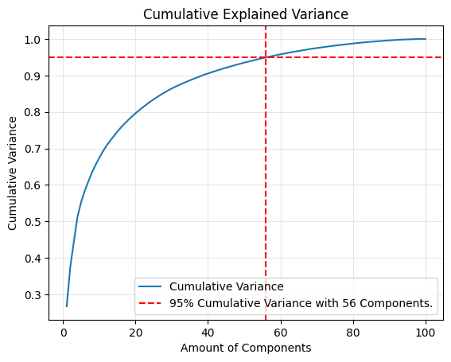

```python
# ----------------------------------------- Version 2: PCA -----------------------------------------

# ============================================================
# Genrating new Class for easier PCA-Feature-Ranking Analysis
# ============================================================
class PCA_Analyis():

    def __init__(self, feature_data):
        self.scaler = StandardScaler()          # Needed to avoid data leakage!
        self.features_std = pd.DataFrame(self.scaler.fit_transform(feature_data), columns=feature_data.columns)
        self.pca_result = PCA().fit(self.features_std)  # fit() learns only the coefficients for the linear combinations of the components.
        self.component_ranking_pca = pd.DataFrame(self.pca_result.components_.T,                    # => shape = (weigth_feature, component)
                                                  columns=[f"component_{i}" for i in range(1, 101)],
                                                  index=feature_data.columns)
        self.transformed_data = pd.DataFrame(self.pca_result.transform(self.features_std),
                                             columns=[f"PC{i+1}" for i in range(100)])

    # Cumulative Variance
    def cum_var(self):
        cum_var = pd.DataFrame({
            "variance_ratio": self.pca_result.explained_variance_ratio_,
            "cumulative_variance_ratio": np.cumsum(self.pca_result.explained_variance_ratio_)
        },
        index=self.component_ranking_pca.columns)
        return cum_var

    # Visualizing Cumulative Variance
    def vis_cum_var(self):
        plt.plot(range(1, len(self.cum_var()) + 1), self.cum_var()["cumulative_variance_ratio"], linestyle="-", label="Cumulative Variance")
        plt.axhline(y=0.95,
                    color="r",
                    linestyle='--',
                    label=f"95% Cumulative Variance with {len(self.cum_var()[self.cum_var()["cumulative_variance_ratio"] <= 0.95])} Components.")
        plt.xlabel("Amount of Components")
        plt.ylabel("Cumulative Variance")
        plt.title("Cumulative Explained Variance")
        plt.legend(loc = "lower right")
        plt.grid(True, alpha=0.3)
        plt.axvline(len(self.cum_var()[self.cum_var()["cumulative_variance_ratio"] <= 0.95]),
                    color="r",
                    linestyle="--")

    def transform_test_data(self, X_test):
        return pd.DataFrame(self.pca_result.transform(self.scaler.transform(X_test)),
                            columns=[f"PC{i+1}" for i in range(100)])

    def best_pca_param(self):
        return len(self.cum_var()[self.cum_var()["cumulative_variance_ratio"] <= 0.95])

pca_analysis = PCA_Analyis(features)
pca_analysis.vis_cum_var()
```

### Train a classifier

Let's prepare train and test data

```python
# ----------------------------------- Version 2: Gini-Importance -----------------------------------

X = features[feature_ranking["Feature"][0:32]]
len(X.columns)
y = filtered_dataset["genre"]
len(y) == len(X)

X_train, X_test, y_train, y_test = train_test_split(X, y, test_size=0.2, random_state=42)

# ----------------------------------------- Version 2: PCA -----------------------------------------
X_train_pca, X_test_pca, y_train_pca, y_test_pca = train_test_split(features, filtered_dataset["genre"], test_size=0.2, random_state=42)

X_train_pca = PCA_Analyis(X_train_pca)
X_test_pca = X_train_pca.transform_test_data(X_test_pca).iloc[:, :X_train_pca.best_pca_param()]
X_train_pca = X_train_pca.transformed_data.iloc[:, :X_train_pca.best_pca_param()]

len(y_train_pca) == len(X_train_pca)
```

```
True
```

The best practice is to use a pipeline because it allows us to streamline preprocessing steps (like scaling) and model training into a single workflow. This ensures that all steps are applied consistently during both training and testing, preventing data leakage and simplifying cross-validation and hyperparameter tuning.

```python
# ----------------------------------- Version 2: Gini-Importance -----------------------------------

pipeline = Pipeline([
    ('scaler', StandardScaler()),
    ('classifier', LogisticRegression(max_iter=1000, random_state=42))
])

pipeline.fit(X_train, y_train)
y_pred = pipeline.predict(X_test)

accuracy = accuracy_score(y_test, y_pred)
print(f"{pipeline['classifier'].__class__.__name__}: {accuracy}")
```

```
LogisticRegression: 0.7705882352941177
```

```python
# ----------------------------------------- Version 2: PCA -----------------------------------------
# No need for a Pipeline because of already standardized data in the data preparation!
# Since for PCA-feature extraction standardization was already needed.

model_1 = LogisticRegression()
model_1.fit(X_train_pca, y_train_pca)
y_pred_pca = model_1.predict(X_test_pca)
accuracy_1 = model_1.score(X_test_pca, y_test_pca)
print(f"LogisticRegression with PCA-Features: {accuracy_1}")
```

```
LogisticRegression with PCA-Features: 0.7411764705882353
```

**Train other models and compare their performance**

Try training different models (at least 3) from sklearn and boosting libraries (e.g. Random Forest, SVM, Gradient Boosting, etc)

```python
# ==============
# Random Forest
# ==============
# For the Random Forest we will stick with the feature-selection based on the Feature-Ranking of the Random Forest.
# Also we will use the same already splitted data (The same we also used in the Logistic Regression):
X_train.head()
X_test.head()
y_train[0:5]
y_test[0:5]

# --- Training of the Random Forest ---
rf_model = RandomForestClassifier(n_estimators=500,
                                  max_depth=20,
                                  random_state=42)
rf_model.fit(X_train, y_train)
print(f"Random-Forest Acurracy: {rf_model.score(X_test, y_test):.3f}")
```

```
Random-Forest Acurracy: 0.724
```

```python
# ===========
# XGBoosting
# ===========
# For the XGBoost we will also stick with the feature-selection based on the Feature-Ranking done with the Random Forest
# for the Logistic Regression. Also we will use the same already splitted data:
X_train.head()
X_test.head()
y_train[0:5]
y_test[0:5]

# --- Training of the XGBoosting ---
xgb_model = xgb.XGBClassifier(
    random_state=42,
    eval_metric='logloss'  # For Classification
)

xgb_model.fit(X_train, y_train)
y_pred = xgb_model.predict(X_test)
accuracy = accuracy_score(y_test, y_pred)

print(f"XGBoost Accuracy: {accuracy}")
```

```
XGBoost Accuracy: 0.7294117647058823
```

```python
# ========================
# Support Vector Machines
# ========================
X_train.head()
X_test.head()
y_train[0:5]
y_test[0:5]
# -> Needs standardized Data!
pipeline = Pipeline([
    ('scaler', StandardScaler()),
    ('svm', SVC(random_state=42))
])

# --- Training of SVM ---
pipeline.fit(X_train, y_train)

y_pred = pipeline.predict(X_test)
accuracy = accuracy_score(y_test, y_pred)

print(f"SVM Accuracy: {accuracy}")
```

```
SVM Accuracy: 0.7411764705882353
```

**(ADV) Choose several best models and perform parametric grid search**

Choose several of the best-performing models from your previous experiments and tune their hyperparameters using a parametric grid search. Compare the results and discuss which combination performs best.

```python
# ===================================
# GridSearchCV for the Random Forest
# ===================================
# Runtime in Colab: 18 Min

param_grid = {
    'n_estimators': [500, 700, 1000],
    'max_features': ['sqrt', "log2"],
    'max_depth': [None, 10, 20],
    'min_samples_split': [2, 10, 20],
    'min_samples_leaf': [1, 5, 10]
}

rf = RandomForestClassifier(random_state=42)
grid_search = GridSearchCV(rf, param_grid, cv=3, n_jobs=-1) # n_jobs = -1 => All available CPU-Kernels ???? are used
grid_search.fit(X_train, y_train)

print("Best Parameters:\n", grid_search.best_params_)
print(f"Acc of best Model in GridSearchCV:{grid_search.best_score_}")

# --- Applying best Parameters to Complete Dataset ---
rf_model_final = RandomForestClassifier(n_estimators=1000,
                                        max_depth=None,
                                        random_state=42)
rf_model_final.fit(X_train, y_train)
print(f"Random-Forest Acurracy: {rf_model_final.score(X_test, y_test):.3f}")
```

```
Best Parameters:
 {'max_depth': None, 'max_features': 'sqrt', 'min_samples_leaf': 1, 'min_samples_split': 2, 'n_estimators': 1000}
Acc of best Model in GridSearchCV:0.6946902654867255
Random-Forest Acurracy: 0.729
```

```
The improvement through the GridSearchCV in the Random Forest was extremly small. For greater Accuracy one should consider to optimize the features since the features used here are based on the feature-ranking made for the Logistic Regression. Random Forest might prefer other features.
```

```python
# =========================================
# GridSearchCV for the Logistic Regression
# =========================================
pipeline = Pipeline([
    ('scaler', StandardScaler()),
    ('lr', LogisticRegression(max_iter=1000, random_state=42))
])

# Parameter Grid
param_grid = {
    'lr__C': [0.001, 0.01, 0.1, 1, 10, 100],
    'lr__solver': ['liblinear', 'saga', "lbfgs"],
    'lr__class_weight': [None, 'balanced']
}

grid_search = GridSearchCV(
    pipeline,
    param_grid,
    cv=3,
    n_jobs=-1
)
grid_search.fit(X_train, y_train)

print(f"Best Parameters:\n{grid_search.best_params_}")
print(f"Acc of best Model in GridSearchCV: {grid_search.best_score_:.3f}")

# --- Applying best Parameters to Complete Dataset ---
pipeline = Pipeline([
    ('scaler', StandardScaler()),
    ('lr', LogisticRegression(max_iter=1000,
                              random_state=42,
                              C=1,
                              class_weight=None,
                              solver="saga"))
])
pipeline.fit(X_train, y_train)

print(f"Logistic-Regression Acurracy: {pipeline.score(X_test, y_test):.3f}")
print(f"Improvment of GridSearchCV: {pipeline.score(X_test, y_test) - accuracy}")
```

```
Best Parameters:
{'lr__C': 1, 'lr__class_weight': None, 'lr__solver': 'saga'}
Acc of best Model in GridSearchCV: 0.712
Logistic-Regression Acurracy: 0.771
Improvment of GridSearchCV: 0.02941176470588236
```

```
Model Accuracy: 0.7706
              precision    recall  f1-score   support

           0       0.79      0.65      0.71        23
           1       1.00      0.90      0.95        21
           2       0.61      0.69      0.65        16
           3       0.73      0.73      0.73        15
           4       0.71      0.75      0.73        16
           5       0.89      0.89      0.89        18
           6       0.79      0.94      0.86        16
           7       0.94      0.79      0.86        19
           8       0.60      0.75      0.67        12
           9       0.57      0.57      0.57        14

    accuracy                           0.77       170
   macro avg       0.76      0.77      0.76       170
weighted avg       0.78      0.77      0.77       170
```

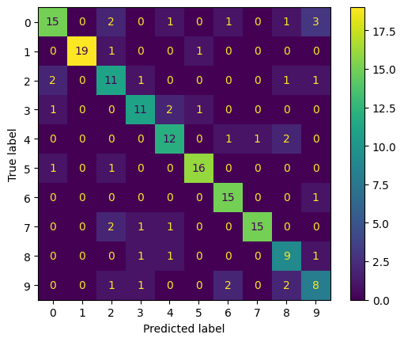

```python
# Confusion Matrix of the Logistic Regression
y_pred = pipeline.predict(X_test)

accuracy_lg = accuracy_score(y_test, y_pred)
print(f"Model Accuracy: {accuracy_lg:.4f}")
print(classification_report(y_test, y_pred))

ConfusionMatrixDisplay.from_estimator(pipeline, X_test, y_test)
plt.show()
```

```
As we saw, also here within the Logistic Regression, the GridSearchCV didn't improve the Accuracy. Means, the most important step within the Logistic Regression was to optimize the Features instead of the Hyperparameters.
```

```python
# =============================
# GridSearchCV for the XGBoost
# =============================
# Runtime in Colab: 13 Min

param_grid = {
    'n_estimators': [300, 400, 500],        # Amount of estimated Trees
    'learning_rate': [0.2, 0.3, 0.4],       # Learning Rate
    'max_depth': [2, 3, 5],                 # Amount of Nods in the Trees
    'subsample': [0.7, 0.8, 0.9],           # Only use X% of the available Feature data per tree (but use all Feature columns)
    'colsample_bytree': [0.8, 0.9, 1]       # # Only use X% of the available Feature columns per tree
}
xgb_model = xgb.XGBClassifier(
    random_state=42,
    eval_metric='logloss'
)
grid_search = GridSearchCV(
    xgb_model,
    param_grid,
    cv=3,
    scoring='accuracy',
    n_jobs=-1
)
grid_search.fit(X_train, y_train)

print(f"Best Parameters:\n{grid_search.best_params_}")
print(f"Acc of best Model in GridSearchCV: {grid_search.best_score_}")

# --- Applying best Parameters to Complete Dataset ---
xgb_model_final = xgb.XGBClassifier(
    random_state=42,
    eval_metric='logloss',
    n_estimators=500,
    learning_rate=0.2,
    max_depth=3,
    subsample=0.9,
    colsample_bytree=0.9
)

xgb_model_final.fit(X_train, y_train)
print(f"XGBoost Acurracy: {xgb_model_final.score(X_test, y_test)}")
```

```
Best Parameters:
{'colsample_bytree': 0.9, 'learning_rate': 0.2, 'max_depth': 3, 'n_estimators': 500, 'subsample': 0.9}
Acc of best Model in GridSearchCV: 0.743362831858407
XGBoost Acurracy: 0.7411764705882353
```

[output not shown]

```python
# =============================================
# GridSearchCV for the Support Vector Machines
# =============================================
pipeline = Pipeline([
    ('scaler', StandardScaler()),
    ('svm', SVC(random_state=42))
])
param_grid = {
    'svm__C': [0.1, 1, 10, 100],
    'svm__kernel': ['rbf', "linear"]
}
grid_search = GridSearchCV(
    pipeline,
    param_grid,
    cv=3,
    scoring='accuracy',
    n_jobs=-1
)
svm_model = grid_search.fit(X_train, y_train)

print(f"Best Parameters:\n{grid_search.best_params_}")
print(f"Acc of best Model in GridSearchCV: {grid_search.best_score_}")

# --- Applying best Parameters to Complete Dataset ---
pipeline = Pipeline([
    ('scaler', StandardScaler()),
    ('svm', SVC(random_state=42, C=10))
])

svm_model_final = pipeline.fit(X_train, y_train)
print(f"SVM Accuracy: {svm_model_final.score(X_test, y_test)}")
```

```
Best Parameters:
{'svm__C': 10, 'svm__kernel': 'rbf'}
Acc of best Model in GridSearchCV: 0.7389380530973452
SVM Accuracy: 0.7647058823529411
```

```
For the SVM the Grid Search had some effectivness, pushing the accuracy for arround 2 pp.
```